Gad vide om.. dThis is an R Markdown document. Markdown is a simple formatting syntax for authoring HTML, PDF, and MS Word documents. For more details on using R Markdown see http://rmarkdown.rstudio.com.

hvorfor ikke

You can also embed plots, jfor example:

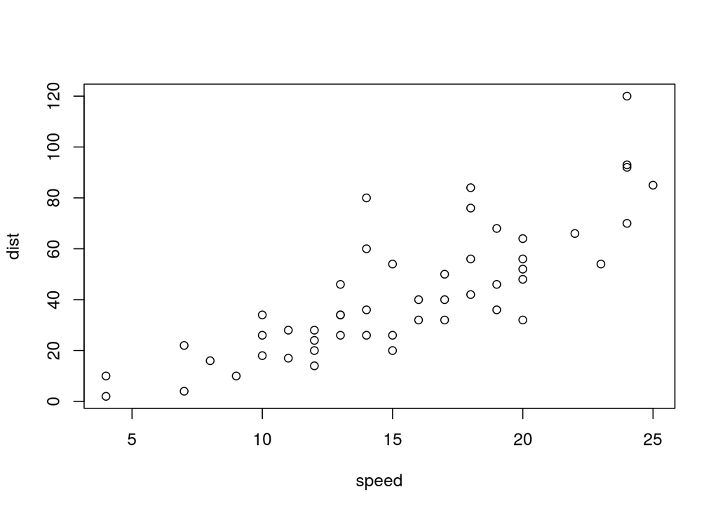

# Starten på mit afsnit, load data

```r
setwd("/home/emil/Dropbox/Speciale/Emil_Soeren")
source("./statistik/R/moneca/vores/vorescripts/0_funktioner_og_pakker.R")
source("./statistik/R/moneca/vores/vorescripts/0_funktion_mobilitetsanalysemotor.multi.R")
source("./statistik/R/moneca/vores/vorescripts/0_funktion_mobilitetsanalysemotor.uni.R")


load("./statistik/R/moneca/vores/voresdata/Rnotebook_allebeskaeft250.Rdata")
save.image("./statistik/R/moneca/vores/voresdata/Rnotebook_allebeskaeft250.Rdata")
library(forcats)
library(DescTools)
library(ggthemes)
library(knitr)
```

## Social klasse

overordnet om klasserne

```
##                                Freq Kum      rela     KuRela
## 1 Borgerskab                      0   0  0.000000   0.000000
## 2 Småborgerskab                   9   9  3.296703   3.296703
## 3 Teknikere                      37  46 13.553114  16.849817
## 4 Manuelle arbejdere             94 140 34.432234  51.282051
## 5 Managere                       45 185 16.483516  67.765568
## 6 Clerks                         17 202  6.227106  73.992674
## 7 Sociokulturelle specialister   34 236 12.454212  86.446886
## 8 Servicearbejdere               29 265 10.622711  97.069597
## Uklassicificeret                  8 273  2.930403 100.000000
```

```
##                                       Freq Kum       rela     KuRela
## 1 Store forretningsdrivende              0   0  0.0000000   0.000000
## 2 Selvstaendige profesionelle            0   0  0.0000000   0.000000
## 3 Smaa forretningsdrivende m. ansatte    4   4  1.4652015   1.465201
## 4 Smaa forretningsdrivende u. ansatte    5   9  1.8315018   3.296703
## 5 Teknikere (eksperter)                 16  25  5.8608059   9.157509
## 6 Teknikere                             21  46  7.6923077  16.849817
## 7 Manuelle arbejdere, hoejt niveau      51  97 18.6813187  35.531136
## 8 Manuelle arbejdere, lavt niveau       43 140 15.7509158  51.282051
## 9 Managere, hoejt niveau                24 164  8.7912088  60.073260
## 10 Managere, lavt niveau                21 185  7.6923077  67.765568
## 11 Clerks, hoejt niveau                 15 200  5.4945055  73.260073
## 12 Clerks, lavt niveau                   2 202  0.7326007  73.992674
## 13 Sociokulturelle profesionelle        17 219  6.2271062  80.219780
## 14 Sociokulturelle semiprofessionelle   17 236  6.2271062  86.446886
## 15 Servicearbejdere, hoejt niveau       14 250  5.1282051  91.575092
## 16 Servicearbejdere, lavt niveau        15 265  5.4945055  97.069597
## Uklassicificeret                         8 273  2.9304029 100.000000
```

Sådan er andelen af af klasserne fordelt. Hvordan ser det ud over tid?

Pas på her: Du bruger sammensmeltningen af Oesch og dine Segmenter. har du ikke antal beskæftigede i Oesch Klasser i sig selv? → Nej. Pis. Så, det skal du lige huske at tage forbehold for. Der er en vis unøjagtighed i de præcise andele. Husk på det, undersøg hvad det betyder. #todo

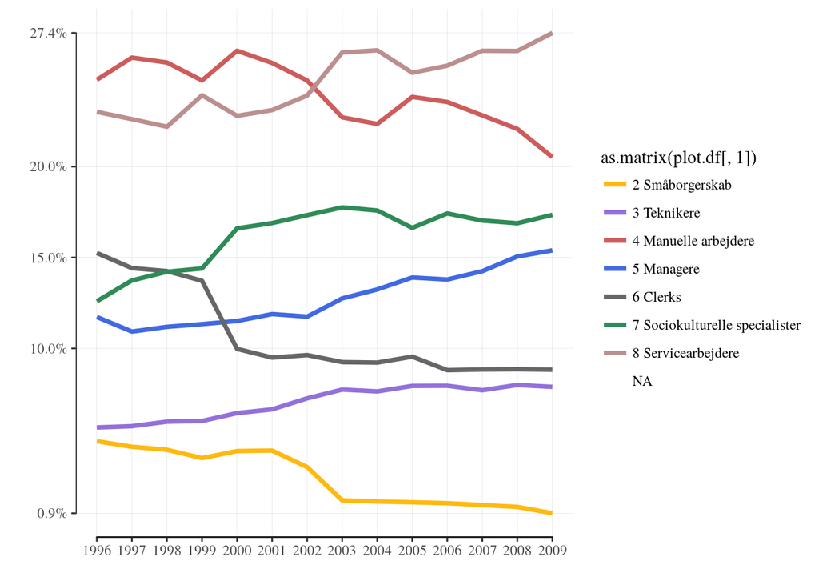

SÅ godt for de store klasser. Det ses, der er noget om snakken ifht hvor arbejdet lægger henne.

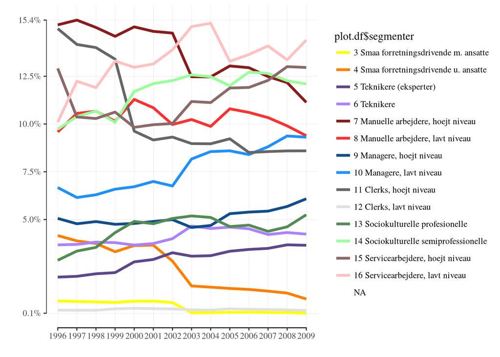

to-do:

- efteruddannelse etc. de nye overenskomstforhandlinger, 200 millioner til efteruddannelse. IT-bølgen kommer. Find citat fra fagforeningsboss om det.
- gå over til køn derefter.

# De manuelle arbejder klynger

Oesch rammer rigtigt med sit 8-klasse skema på arbejderklassen. Og semi-rigtigt på 16-niveau. Permabilitet er vigtigt for en klase, og vi kan se at indenfor klassefraktioner er overlap, som der vel sådan set også burde være. Alligevel er der også tydelig forskel

NB! Her er der kode der ikke kan køres, fordi jeg importerer data i hånden. Men det findes i specialet.

[figure not shown]

Ok, har skrevet om det i specialet.

### Hvor går den manuelle klasse hen?

Vigtigt: I Oesch optik er “børnepasning i private hjem” et “højere” servicefag. Nej. Det er det ikke. Det er rejseleder heller ikke. Dem omkoder jeg.